# This is a notebook to aid in the development of the market simulator. One initial version was created as part of the Machine Learning for Trading course. It has to be adapted for use in the Capstone project.

```python
# Basic imports
import os
import pandas as pd
import matplotlib.pyplot as plt
import numpy as np
import datetime as dt
import scipy.optimize as spo
import sys
from time import time
from sklearn.metrics import r2_score, median_absolute_error

%matplotlib inline

%pylab inline
pylab.rcParams['figure.figsize'] = (20.0, 10.0)

%load_ext autoreload
%autoreload 2

sys.path.append('../../')

from utils import analysis
```

```
The autoreload extension is already loaded. To reload it, use:
  %reload_ext autoreload
```

### To use the market simulator with the q-learning agent it must be possible to call it with custom data, stored in RAM. Let's try that.

```python
from utils import marketsim as msim
```

```python
orders_path = '../../data/orders/orders-my-leverage.csv'
orders_df = pd.read_csv(orders_path, index_col='Date', parse_dates=True, na_values=['nan'])
```

```python
orders_df
```

| Date | Symbol | Order | Shares |
| --- | --- | --- | --- |
| 2011-01-10 | AAPL | BUY | 1500 |
| 2011-01-13 | AAPL | SELL | 1500 |
| 2011-01-13 | IBM | BUY | 4000 |
| 2011-01-26 | GOOG | BUY | 100000 |
| 2011-02-02 | XOM | SELL | 4000 |
| 2011-02-10 | XOM | BUY | 4000 |
| 2011-03-03 | GOOG | SELL | 1000 |
| 2011-03-03 | IBM | SELL | 2200 |
| 2011-06-03 | IBM | SELL | 3300 |
| 2011-05-03 | IBM | BUY | 1500 |
| 2011-06-10 | AAPL | BUY | 1200 |
| 2011-08-01 | GOOG | BUY | 55 |
| 2011-08-01 | GOOG | SELL | 55 |
| 2011-12-20 | AAPL | SELL | 1200 |

```python
data_df = pd.read_pickle('../../data/data_df.pkl')
port_vals_df, values = msim.simulate_orders(orders_df, data_df)
```

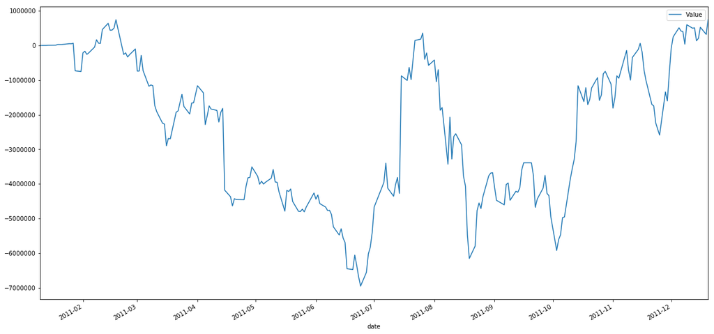

```python
port_vals_df.plot()
```

```python
values
```

| date | SPY | AAPL | GOOG | IBM | XOM | CASH |
| --- | --- | --- | --- | --- | --- | --- |
| 2011-01-10 | 0.0 | 73380.0 | 0.0 | 0.0 | 0.0 | -72380.0 |
| 2011-01-11 | 0.0 | 73215.0 | 0.0 | 0.0 | 0.0 | -72380.0 |
| 2011-01-12 | 0.0 | 73800.0 | 0.0 | 0.0 | 0.0 | -72380.0 |
| 2011-01-13 | 0.0 | 0.0 | 0.0 | 595280.0 | 0.0 | -593590.0 |
| 2011-01-14 | 0.0 | 0.0 | 0.0 | 600000.0 | 0.0 | -593590.0 |
| 2011-01-18 | 0.0 | 0.0 | 0.0 | 602600.0 | 0.0 | -593590.0 |
| 2011-01-19 | 0.0 | 0.0 | 0.0 | 622760.0 | 0.0 | -593590.0 |
| 2011-01-20 | 0.0 | 0.0 | 0.0 | 623200.0 | 0.0 | -593590.0 |
| 2011-01-21 | 0.0 | 0.0 | 0.0 | 622000.0 | 0.0 | -593590.0 |
| 2011-01-24 | 0.0 | 0.0 | 0.0 | 638520.0 | 0.0 | -593590.0 |
| 2011-01-25 | 0.0 | 0.0 | 0.0 | 645760.0 | 0.0 | -593590.0 |
| 2011-01-26 | 0.0 | 0.0 | 30794000.0 | 644160.0 | 0.0 | -31387590.0 |
| 2011-01-27 | 0.0 | 0.0 | 30809000.0 | 644280.0 | 0.0 | -31387590.0 |
| 2011-01-28 | 0.0 | 0.0 | 30019000.0 | 636840.0 | 0.0 | -31387590.0 |
| 2011-01-31 | 0.0 | 0.0 | 29988000.0 | 648000.0 | 0.0 | -31387590.0 |
| 2011-02-01 | 0.0 | 0.0 | 30521000.0 | 654240.0 | 0.0 | -31387590.0 |
| 2011-02-02 | 0.0 | 0.0 | 30569000.0 | 653200.0 | -333640.0 | -31053950.0 |
| 2011-02-03 | 0.0 | 0.0 | 30477000.0 | 654120.0 | -333760.0 | -31053950.0 |
| 2011-02-04 | 0.0 | 0.0 | 30518000.0 | 656000.0 | -333120.0 | -31053950.0 |
| 2011-02-07 | 0.0 | 0.0 | 30684000.0 | 659280.0 | -335720.0 | -31053950.0 |
| 2011-02-08 | 0.0 | 0.0 | 30888000.0 | 664200.0 | -331920.0 | -31053950.0 |
| 2011-02-09 | 0.0 | 0.0 | 30794000.0 | 658600.0 | -330200.0 | -31053950.0 |
| 2011-02-10 | 0.0 | 0.0 | 30791000.0 | 656360.0 | 0.0 | -31386750.0 |
| 2011-02-11 | 0.0 | 0.0 | 31194000.0 | 655400.0 | 0.0 | -31386750.0 |
| 2011-02-14 | 0.0 | 0.0 | 31376000.0 | 652880.0 | 0.0 | -31386750.0 |
| 2011-02-15 | 0.0 | 0.0 | 31176000.0 | 651360.0 | 0.0 | -31386750.0 |
| 2011-02-16 | 0.0 | 0.0 | 31180000.0 | 653600.0 | 0.0 | -31386750.0 |
| 2011-02-17 | 0.0 | 0.0 | 31232000.0 | 656960.0 | 0.0 | -31386750.0 |
| 2011-02-18 | 0.0 | 0.0 | 31472000.0 | 659360.0 | 0.0 | -31386750.0 |
| 2011-02-22 | 0.0 | 0.0 | 30480000.0 | 647800.0 | 0.0 | -31386750.0 |
| ... | ... | ... | ... | ... | ... | ... |
| 2011-11-08 | 0.0 | 69636.0 | 30280140.0 | 0.0 | 0.0 | -30493126.0 |
| 2011-11-09 | 0.0 | 67764.0 | 29716830.0 | 0.0 | 0.0 | -30493126.0 |
| 2011-11-10 | 0.0 | 66036.0 | 29426760.0 | 0.0 | 0.0 | -30493126.0 |
| 2011-11-11 | 0.0 | 65940.0 | 30083130.0 | 0.0 | 0.0 | -30493126.0 |
| 2011-11-14 | 0.0 | 65016.0 | 30312810.0 | 0.0 | 0.0 | -30493126.0 |
| 2011-11-15 | 0.0 | 66660.0 | 30489030.0 | 0.0 | 0.0 | -30493126.0 |
| 2011-11-16 | 0.0 | 65964.0 | 30237570.0 | 0.0 | 0.0 | -30493126.0 |
| 2011-11-17 | 0.0 | 64704.0 | 29712870.0 | 0.0 | 0.0 | -30493126.0 |
| 2011-11-18 | 0.0 | 64272.0 | 29416860.0 | 0.0 | 0.0 | -30493126.0 |
| 2011-11-21 | 0.0 | 63264.0 | 28727820.0 | 0.0 | 0.0 | -30493126.0 |
| 2011-11-22 | 0.0 | 64548.0 | 28681290.0 | 0.0 | 0.0 | -30493126.0 |
| 2011-11-23 | 0.0 | 62916.0 | 28192230.0 | 0.0 | 0.0 | -30493126.0 |
| 2011-11-25 | 0.0 | 62328.0 | 27840780.0 | 0.0 | 0.0 | -30493126.0 |
| 2011-11-28 | 0.0 | 64476.0 | 29086200.0 | 0.0 | 0.0 | -30493126.0 |
| 2011-11-29 | 0.0 | 63972.0 | 28825830.0 | 0.0 | 0.0 | -30493126.0 |
| 2011-11-30 | 0.0 | 65520.0 | 29640600.0 | 0.0 | 0.0 | -30493126.0 |
| 2011-12-01 | 0.0 | 66504.0 | 30351420.0 | 0.0 | 0.0 | -30493126.0 |
| 2011-12-02 | 0.0 | 66804.0 | 30677130.0 | 0.0 | 0.0 | -30493126.0 |
| 2011-12-05 | 0.0 | 67368.0 | 30938490.0 | 0.0 | 0.0 | -30493126.0 |
| 2011-12-06 | 0.0 | 67020.0 | 30845430.0 | 0.0 | 0.0 | -30493126.0 |
| 2011-12-07 | 0.0 | 66696.0 | 30826620.0 | 0.0 | 0.0 | -30493126.0 |
| 2011-12-08 | 0.0 | 66972.0 | 30464280.0 | 0.0 | 0.0 | -30493126.0 |
| 2011-12-09 | 0.0 | 67476.0 | 31026600.0 | 0.0 | 0.0 | -30493126.0 |
| 2011-12-12 | 0.0 | 67176.0 | 30925620.0 | 0.0 | 0.0 | -30493126.0 |
| 2011-12-13 | 0.0 | 66648.0 | 30937500.0 | 0.0 | 0.0 | -30493126.0 |
| 2011-12-14 | 0.0 | 65172.0 | 30564270.0 | 0.0 | 0.0 | -30493126.0 |
| 2011-12-15 | 0.0 | 64956.0 | 30636540.0 | 0.0 | 0.0 | -30493126.0 |
| 2011-12-16 | 0.0 | 65316.0 | 30954330.0 | 0.0 | 0.0 | -30493126.0 |
| 2011-12-19 | 0.0 | 65520.0 | 30749400.0 | 0.0 | 0.0 | -30493126.0 |
| 2011-12-20 | 0.0 | 0.0 | 31172130.0 | 0.0 | 0.0 | -30425254.0 |

240 rows × 6 columns

```
sharpeRatio = 0.738002
cumRet = 745.876000
sdDReturn = 1.571614
averageDReturn = 0.073064
Final Value: 746876.000000
```

```
(Value    0.738002
 dtype: float64, Value    745.876
 dtype: float64, Value    0.073064
 dtype: float64, Value    1.571614
 dtype: float64, Value    746.876000
 SPY        0.975587
 Name: 2011-12-20 00:00:00, dtype: float64)
```

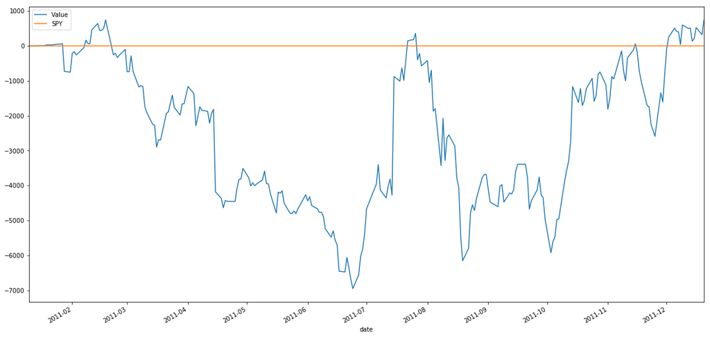

```python
analysis.value_eval(port_vals_df, graph=True, verbose=True, data_df=data_df)
```

## That function has many of the desired characteristics, but doesn't follow the dynamics necessary for the interaction with the agent. The solution will be to implement a new class, called Portfolio, that will accept orders, keep track of the positions and return their values when asked for.

```python
'AAPL' in data_df.columns.tolist()
```

```
True
```

```python
data_df.index.get_level_values(0)[0]
```

```
Timestamp('1993-01-29 00:00:00')
```

```python
symbols = data_df.columns.get_level_values(0).tolist()
```

```python
symbols.append('CASH')
positions_df = pd.DataFrame(index=symbols, columns=['shares', 'value'])
positions_df
```

|  | shares | value |
| --- | --- | --- |
| SPY | NaN | NaN |
| MMM | NaN | NaN |
| ABT | NaN | NaN |
| ABBV | NaN | NaN |
| ACN | NaN | NaN |
| ATVI | NaN | NaN |
| AYI | NaN | NaN |
| ADBE | NaN | NaN |
| AMD | NaN | NaN |
| AAP | NaN | NaN |
| AES | NaN | NaN |
| AET | NaN | NaN |
| AMG | NaN | NaN |
| AFL | NaN | NaN |
| A | NaN | NaN |
| APD | NaN | NaN |
| AKAM | NaN | NaN |
| ALK | NaN | NaN |
| ALB | NaN | NaN |
| ARE | NaN | NaN |
| ALXN | NaN | NaN |
| ALLE | NaN | NaN |
| AGN | NaN | NaN |
| ADS | NaN | NaN |
| LNT | NaN | NaN |
| ALL | NaN | NaN |
| GOOGL | NaN | NaN |
| GOOG | NaN | NaN |
| MO | NaN | NaN |
| AMZN | NaN | NaN |
| ... | ... | ... |
| VMC | NaN | NaN |
| WMT | NaN | NaN |
| WBA | NaN | NaN |
| DIS | NaN | NaN |
| WM | NaN | NaN |
| WAT | NaN | NaN |
| WEC | NaN | NaN |
| WFC | NaN | NaN |
| HCN | NaN | NaN |
| WDC | NaN | NaN |
| WU | NaN | NaN |
| WRK | NaN | NaN |
| WY | NaN | NaN |
| WHR | NaN | NaN |
| WFM | NaN | NaN |
| WMB | NaN | NaN |
| WLTW | NaN | NaN |
| WYN | NaN | NaN |
| WYNN | NaN | NaN |
| XEL | NaN | NaN |
| XRX | NaN | NaN |
| XLNX | NaN | NaN |
| XL | NaN | NaN |
| XYL | NaN | NaN |
| YHOO | NaN | NaN |
| YUM | NaN | NaN |
| ZBH | NaN | NaN |
| ZION | NaN | NaN |
| ZTS | NaN | NaN |
| CASH | NaN | NaN |

504 rows × 2 columns

```python
close_df = data_df.xs('Close', level='feature')
close_df.head()
```

| date | SPY | MMM | ABT | ABBV | ACN | ATVI | AYI | ADBE | AMD | AAP | ... | XEL | XRX | XLNX | XL | XYL | YHOO | YUM | ZBH | ZION | ZTS |
| --- | --- | --- | --- | --- | --- | --- | --- | --- | --- | --- | --- | --- | --- | --- | --- | --- | --- | --- | --- | --- | --- |
| 1993-01-29 | 43.94 | 24.50 | 6.88 | NaN | NaN | NaN | NaN | 2.59 | 18.75 | NaN | ... | 22.00 | 14.28 | 2.50 | NaN | NaN | NaN | NaN | NaN | 10.94 | NaN |
| 1993-02-01 | 44.25 | 24.69 | 6.88 | NaN | NaN | NaN | NaN | 2.72 | 19.12 | NaN | ... | 22.19 | 14.09 | 2.62 | NaN | NaN | NaN | NaN | NaN | 11.06 | NaN |
| 1993-02-02 | 44.34 | 24.72 | 6.53 | NaN | NaN | NaN | NaN | 2.84 | 20.25 | NaN | ... | 22.06 | 14.09 | 2.64 | NaN | NaN | NaN | NaN | NaN | 11.12 | NaN |
| 1993-02-03 | 44.81 | 25.19 | 6.91 | NaN | NaN | NaN | NaN | 2.70 | 20.50 | NaN | ... | 22.38 | 14.03 | 2.68 | NaN | NaN | NaN | NaN | NaN | 11.25 | NaN |
| 1993-02-04 | 45.00 | 26.06 | 6.84 | NaN | NaN | NaN | NaN | 2.73 | 20.12 | NaN | ... | 22.81 | 14.15 | 2.67 | NaN | NaN | NaN | NaN | NaN | 11.69 | NaN |

5 rows × 503 columns

```python
current_date = close_df.index[-1]
current_date
```

```
Timestamp('2016-12-30 00:00:00')
```

```python
positions_df['shares'] = np.zeros(positions_df.shape[0])
positions_df.loc['CASH','shares'] = 1000
positions_df
```

|  | shares | value |
| --- | --- | --- |
| SPY | 0.0 | NaN |
| MMM | 0.0 | NaN |
| ABT | 0.0 | NaN |
| ABBV | 0.0 | NaN |
| ACN | 0.0 | NaN |
| ATVI | 0.0 | NaN |
| AYI | 0.0 | NaN |
| ADBE | 0.0 | NaN |
| AMD | 0.0 | NaN |
| AAP | 0.0 | NaN |
| AES | 0.0 | NaN |
| AET | 0.0 | NaN |
| AMG | 0.0 | NaN |
| AFL | 0.0 | NaN |
| A | 0.0 | NaN |
| APD | 0.0 | NaN |
| AKAM | 0.0 | NaN |
| ALK | 0.0 | NaN |
| ALB | 0.0 | NaN |
| ARE | 0.0 | NaN |
| ALXN | 0.0 | NaN |
| ALLE | 0.0 | NaN |
| AGN | 0.0 | NaN |
| ADS | 0.0 | NaN |
| LNT | 0.0 | NaN |
| ALL | 0.0 | NaN |
| GOOGL | 0.0 | NaN |
| GOOG | 0.0 | NaN |
| MO | 0.0 | NaN |
| AMZN | 0.0 | NaN |
| ... | ... | ... |
| VMC | 0.0 | NaN |
| WMT | 0.0 | NaN |
| WBA | 0.0 | NaN |
| DIS | 0.0 | NaN |
| WM | 0.0 | NaN |
| WAT | 0.0 | NaN |
| WEC | 0.0 | NaN |
| WFC | 0.0 | NaN |
| HCN | 0.0 | NaN |
| WDC | 0.0 | NaN |
| WU | 0.0 | NaN |
| WRK | 0.0 | NaN |
| WY | 0.0 | NaN |
| WHR | 0.0 | NaN |
| WFM | 0.0 | NaN |
| WMB | 0.0 | NaN |
| WLTW | 0.0 | NaN |
| WYN | 0.0 | NaN |
| WYNN | 0.0 | NaN |
| XEL | 0.0 | NaN |
| XRX | 0.0 | NaN |
| XLNX | 0.0 | NaN |
| XL | 0.0 | NaN |
| XYL | 0.0 | NaN |
| YHOO | 0.0 | NaN |
| YUM | 0.0 | NaN |
| ZBH | 0.0 | NaN |
| ZION | 0.0 | NaN |
| ZTS | 0.0 | NaN |
| CASH | 1000.0 | NaN |

504 rows × 2 columns

```python
SHARES = 'shares'
VALUE = 'value'
CASH = 'CASH'
```

```python
prices = close_df.loc[current_date]
prices[CASH] = 1.0
positions_df[VALUE] = positions_df[SHARES] * prices
positions_df
```

|  | shares | value |
| --- | --- | --- |
| SPY | 0.0 | 0.0 |
| MMM | 0.0 | 0.0 |
| ABT | 0.0 | 0.0 |
| ABBV | 0.0 | 0.0 |
| ACN | 0.0 | 0.0 |
| ATVI | 0.0 | 0.0 |
| AYI | 0.0 | 0.0 |
| ADBE | 0.0 | 0.0 |
| AMD | 0.0 | 0.0 |
| AAP | 0.0 | 0.0 |
| AES | 0.0 | 0.0 |
| AET | 0.0 | 0.0 |
| AMG | 0.0 | 0.0 |
| AFL | 0.0 | 0.0 |
| A | 0.0 | 0.0 |
| APD | 0.0 | 0.0 |
| AKAM | 0.0 | 0.0 |
| ALK | 0.0 | 0.0 |
| ALB | 0.0 | 0.0 |
| ARE | 0.0 | 0.0 |
| ALXN | 0.0 | 0.0 |
| ALLE | 0.0 | 0.0 |
| AGN | 0.0 | 0.0 |
| ADS | 0.0 | 0.0 |
| LNT | 0.0 | 0.0 |
| ALL | 0.0 | 0.0 |
| GOOGL | 0.0 | 0.0 |
| GOOG | 0.0 | 0.0 |
| MO | 0.0 | 0.0 |
| AMZN | 0.0 | 0.0 |
| ... | ... | ... |
| VMC | 0.0 | 0.0 |
| WMT | 0.0 | 0.0 |
| WBA | 0.0 | 0.0 |
| DIS | 0.0 | 0.0 |
| WM | 0.0 | 0.0 |
| WAT | 0.0 | 0.0 |
| WEC | 0.0 | 0.0 |
| WFC | 0.0 | 0.0 |
| HCN | 0.0 | 0.0 |
| WDC | 0.0 | 0.0 |
| WU | 0.0 | 0.0 |
| WRK | 0.0 | 0.0 |
| WY | 0.0 | 0.0 |
| WHR | 0.0 | 0.0 |
| WFM | 0.0 | 0.0 |
| WMB | 0.0 | 0.0 |
| WLTW | 0.0 | 0.0 |
| WYN | 0.0 | 0.0 |
| WYNN | 0.0 | 0.0 |
| XEL | 0.0 | 0.0 |
| XRX | 0.0 | 0.0 |
| XLNX | 0.0 | 0.0 |
| XL | 0.0 | 0.0 |
| XYL | 0.0 | 0.0 |
| YHOO | 0.0 | 0.0 |
| YUM | 0.0 | 0.0 |
| ZBH | 0.0 | 0.0 |
| ZION | 0.0 | 0.0 |
| ZTS | 0.0 | 0.0 |
| CASH | 1000.0 | 1000.0 |

504 rows × 2 columns

```python
ORDER_SYMBOL = 'symbol'
ORDER_ORDER = 'order'
ORDER_SHARES = 'shares'
BUY = 'BUY'
SELL = 'SELL'
NOTHING = 'NOTHING'
order = pd.Series(['AAPL', BUY, 200], index=[ORDER_SYMBOL, ORDER_ORDER, ORDER_SHARES])
order
```

```
symbol    AAPL
order      BUY
shares     200
dtype: object
```

```python
if order[ORDER_ORDER] == 'BUY':
    positions_df.loc[order[ORDER_SYMBOL], SHARES] += order[ORDER_SHARES]
    positions_df.loc[CASH, SHARES] -= order[ORDER_SHARES] * close_df.loc[current_date, order[ORDER_SYMBOL]]
if order[ORDER_ORDER] == 'SELL':
    positions_df.loc[order[ORDER_SYMBOL], SHARES] -= order[ORDER_SHARES]
    positions_df.loc[CASH, SHARES] += order[ORDER_SHARES] * close_df.loc[current_date, order[ORDER_SYMBOL]]
```

```python
positions_df[VALUE] = positions_df[SHARES] * prices
```

```python
positions_df.loc['AAPL']
```

```
shares      200.0
value     23164.0
Name: AAPL, dtype: float64
```

```python
positions_df.loc[CASH]
```

```
shares   -22164.0
value    -22164.0
Name: CASH, dtype: float64
```

```python
close_df.loc[current_date, 'AAPL']
```

```
115.81999999999999
```

```python
116*200
```

```
23200
```

```python
positions_df[VALUE].iloc[:-1]
```

```
SPY      0.0
MMM      0.0
ABT      0.0
ABBV     0.0
ACN      0.0
ATVI     0.0
AYI      0.0
ADBE     0.0
AMD      0.0
AAP      0.0
AES      0.0
AET      0.0
AMG      0.0
AFL      0.0
A        0.0
APD      0.0
AKAM     0.0
ALK      0.0
ALB      0.0
ARE      0.0
ALXN     0.0
ALLE     0.0
AGN      0.0
ADS      0.0
LNT      0.0
ALL      0.0
GOOGL    0.0
GOOG     0.0
MO       0.0
AMZN     0.0
        ...
VNO      0.0
VMC      0.0
WMT      0.0
WBA      0.0
DIS      0.0
WM       0.0
WAT      0.0
WEC      0.0
WFC      0.0
HCN      0.0
WDC      0.0
WU       0.0
WRK      0.0
WY       0.0
WHR      0.0
WFM      0.0
WMB      0.0
WLTW     0.0
WYN      0.0
WYNN     0.0
XEL      0.0
XRX      0.0
XLNX     0.0
XL       0.0
XYL      0.0
YHOO     0.0
YUM      0.0
ZBH      0.0
ZION     0.0
ZTS      0.0
Name: value, Length: 503, dtype: float64
```

```python
values = positions_df[VALUE]
leverage = np.sum(np.abs(values.iloc[:-1])) / (np.sum(values))
```

```python
leverage
```

```
23.164
```

### Let's test the Portfolio class

```python
from recommender.portfolio import Portfolio

p = Portfolio(data_df)
```

```python
from recommender.order import Order
```

```python
o1 = Order(['AAPL', BUY, 150])
print(o1)
```

```
symbol    AAPL
order      BUY
shares     150
dtype: object
```

```python
p.positions_df
```

|  | shares | value |
| --- | --- | --- |
| SPY | 0.0 | 0.0 |
| MMM | 0.0 | 0.0 |
| ABT | 0.0 | 0.0 |
| ABBV | 0.0 | 0.0 |
| ACN | 0.0 | 0.0 |
| ATVI | 0.0 | 0.0 |
| AYI | 0.0 | 0.0 |
| ADBE | 0.0 | 0.0 |
| AMD | 0.0 | 0.0 |
| AAP | 0.0 | 0.0 |
| AES | 0.0 | 0.0 |
| AET | 0.0 | 0.0 |
| AMG | 0.0 | 0.0 |
| AFL | 0.0 | 0.0 |
| A | 0.0 | 0.0 |
| APD | 0.0 | 0.0 |
| AKAM | 0.0 | 0.0 |
| ALK | 0.0 | 0.0 |
| ALB | 0.0 | 0.0 |
| ARE | 0.0 | 0.0 |
| ALXN | 0.0 | 0.0 |
| ALLE | 0.0 | 0.0 |
| AGN | 0.0 | 0.0 |
| ADS | 0.0 | 0.0 |
| LNT | 0.0 | 0.0 |
| ALL | 0.0 | 0.0 |
| GOOGL | 0.0 | 0.0 |
| GOOG | 0.0 | 0.0 |
| MO | 0.0 | 0.0 |
| AMZN | 0.0 | 0.0 |
| ... | ... | ... |
| VMC | 0.0 | 0.0 |
| WMT | 0.0 | 0.0 |
| WBA | 0.0 | 0.0 |
| DIS | 0.0 | 0.0 |
| WM | 0.0 | 0.0 |
| WAT | 0.0 | 0.0 |
| WEC | 0.0 | 0.0 |
| WFC | 0.0 | 0.0 |
| HCN | 0.0 | 0.0 |
| WDC | 0.0 | 0.0 |
| WU | 0.0 | 0.0 |
| WRK | 0.0 | 0.0 |
| WY | 0.0 | 0.0 |
| WHR | 0.0 | 0.0 |
| WFM | 0.0 | 0.0 |
| WMB | 0.0 | 0.0 |
| WLTW | 0.0 | 0.0 |
| WYN | 0.0 | 0.0 |
| WYNN | 0.0 | 0.0 |
| XEL | 0.0 | 0.0 |
| XRX | 0.0 | 0.0 |
| XLNX | 0.0 | 0.0 |
| XL | 0.0 | 0.0 |
| XYL | 0.0 | 0.0 |
| YHOO | 0.0 | 0.0 |
| YUM | 0.0 | 0.0 |
| ZBH | 0.0 | 0.0 |
| ZION | 0.0 | 0.0 |
| ZTS | 0.0 | 0.0 |
| CASH | 1000.0 | 1000.0 |

504 rows × 2 columns

```python
p.positions_df.loc['AAPL']
```

```
shares    0.0
value     0.0
Name: AAPL, dtype: float64
```

```python
p.execute_order(o1)
```

```python
p.positions_df.loc[['AAPL','CASH']]
```

|  | shares | value |
| --- | --- | --- |
| AAPL | 150.0 | 318.0 |
| CASH | 682.0 | 682.0 |

```python
p.add_market_days(1)
```

```python
p.current_date
```

```
Timestamp('1993-02-01 00:00:00')
```

```python
p.positions_df.loc[['AAPL', CASH]]
```

|  | shares | value |
| --- | --- | --- |
| AAPL | 150.0 | 328.5 |
| CASH | 682.0 | 682.0 |

```python
p.add_market_days(1)
```

```python
p.current_date
```

```
Timestamp('1993-02-02 00:00:00')
```

```python
p.positions_df.loc[['AAPL', CASH]]
```

|  | shares | value |
| --- | --- | --- |
| AAPL | 150.0 | 322.5 |
| CASH | 682.0 | 682.0 |

```python
p.positions_df[VALUE].sum()
```

```
1004.5
```

```python
p.execute_order(Order(['AAPL',SELL,100]))
p.positions_df[p.positions_df[SHARES] != 0]
```

|  | shares | value |
| --- | --- | --- |
| AAPL | 50.0 | 107.5 |
| CASH | 897.0 | 897.0 |

### Let's add a leverage limit of 2

```python
p.execute_order(Order(['MSFT',BUY,120]))
p.get_positions()
```

|  | shares | value |
| --- | --- | --- |
| AAPL | 50.0 | 107.5 |
| MSFT | 120.0 | 333.6 |
| CASH | 563.4 | 563.4 |

```python
p.leverage_limit = 2
```

### Let's buy a less than the limit

```python
p.execute_order(Order(['AAPL',BUY, 10]))
p.get_positions()
```

|  | shares | value |
| --- | --- | --- |
| AAPL | 60.0 | 129.0 |
| MSFT | 120.0 | 333.6 |
| CASH | 541.9 | 541.9 |

### Now, let's buy more than the limit

```python
p.execute_order(Order(['AAPL',BUY, 5000]))
p.get_positions()
```

|  | shares | value |
| --- | --- | --- |
| AAPL | 60.0 | 129.0 |
| MSFT | 120.0 | 333.6 |
| CASH | 541.9 | 541.9 |

The last order wasn't executed because the leverage limit was reached. That's good.

### Let's now go short on AAPL, but less than the limit

```python
p.execute_order(Order(['AAPL',SELL, 300]))
p.get_positions()
```

|  | shares | value |
| --- | --- | --- |
| AAPL | -240.0 | -516.0 |
| MSFT | 120.0 | 333.6 |
| CASH | 1186.9 | 1186.9 |

### Now, the same, but this time let's pass the limit.

```python
p.execute_order(Order(['AAPL',SELL, 3000]))
p.get_positions()
```

|  | shares | value |
| --- | --- | --- |
| AAPL | -240.0 | -516.0 |
| MSFT | 120.0 | 333.6 |
| CASH | 1186.9 | 1186.9 |

Nothing happened because the leverage limit was reached. That's ok.

```python
pos = p.get_positions()
pos[VALUE].sum()
```

```
1004.5
```

```python
p.add_market_days(1000)
p.get_positions()
```

|  | shares | value |
| --- | --- | --- |
| AAPL | -240.0 | -144.0 |
| MSFT | 120.0 | 1290.0 |
| CASH | 1186.9 | 1186.9 |

```python
p.add_market_days(6000)
p.get_positions()
```

|  | shares | value |
| --- | --- | --- |
| AAPL | -240.0 | -27796.8 |
| MSFT | 120.0 | 7456.8 |
| CASH | 1186.9 | 1186.9 |

```python
p.get_positions()[VALUE].sum()
```

```
-19153.1
```

```python
p.add_market_days(-7000)  # Back in time...
p.get_positions()
```

|  | shares | value |
| --- | --- | --- |
| AAPL | -240.0 | -508.8 |
| MSFT | 120.0 | 324.0 |
| CASH | 1186.9 | 1186.9 |

```python
p.current_date
```

```
Timestamp('1993-01-29 00:00:00')
```

### Let's try to buy GOOG before it entered the market...

```python
p.close_df.loc[p.current_date, 'GOOG']
```

```
nan
```

```python
p.execute_order(Order(['GOOG', BUY, 100]))
p.get_positions()
```

|  | shares | value |
| --- | --- | --- |
| AAPL | -240.0 | -508.8 |
| MSFT | 120.0 | 324.0 |
| CASH | 1186.9 | 1186.9 |

Ok, nothing happened. That's correct.

### Now, let's add some years and try to buy GOOG again...

```python
# I need to add some cash, because I lost a lot of money shorting AAPL in the last 20 years, and I need to meet the leverage limits.
p.positions_df.loc[CASH, SHARES] = 100000
p.update_values()

p.add_market_days(7200)
p.execute_order(Order(['GOOG', BUY, 100]))
p.get_positions()
```

|  | shares | value |
| --- | --- | --- |
| GOOG | 100.0 | 77182.0 |
| AAPL | -240.0 | -27796.8 |
| MSFT | 120.0 | 7456.8 |
| CASH | 22818.0 | 22818.0 |

Good. This time GOOG was bought! What about the leverage?

```python
p.leverage_limit
```

```
2
```

```python
p.my_leverage_reached()
```

```
False
```

```python
p.get_leverage()
```

[output not shown]

## OK, that is a good portfolio simulator. Now it is still missing an "outer layer" to connect with the learning Agent. That is, a class or function that given the Agent's action, would return the state and reward. The next notebook will be concerned with that.